# Aside

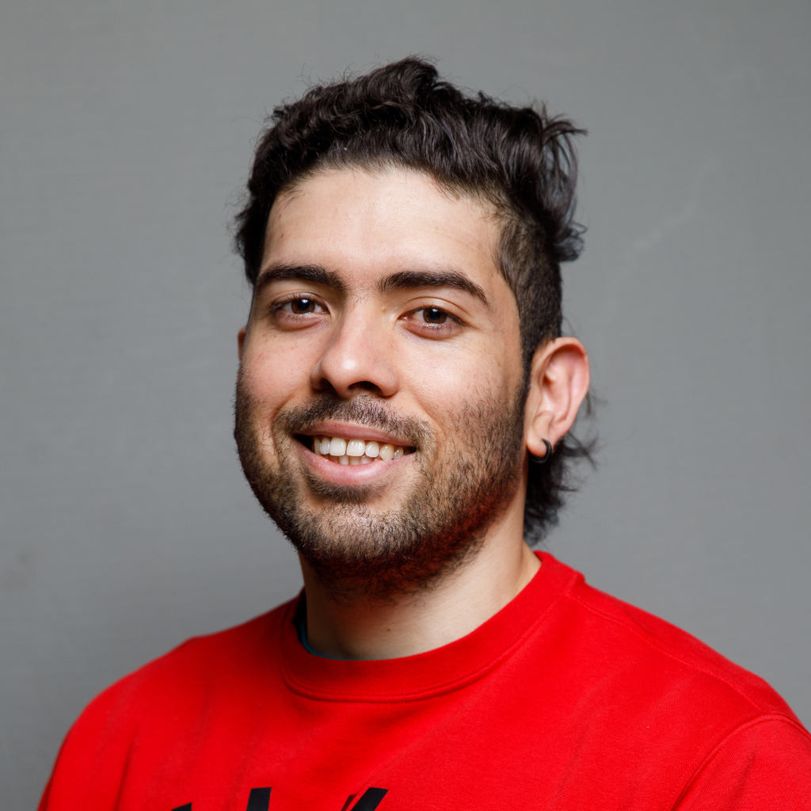

## Contact

- dylan.padilla@yale.edu
- https://github.com/Dylan-Padilla
- https://dylanpadilla.netlify.app/

## Language Skills

R

HTML

Git

CSS

Bash

## Disclaimer

Made with the R package [**pagedown**](https://github.com/rstudio/pagedown).

The source code is available [on github.com/Dylan-Padilla/pagedown-cv](https://github.com/Dylan-Padilla/pagedown-cv).

Last updated on 2025-08-11.

# Main

## Dylan Padilla

I am a G. Evelyn Hutchinson Postdoctoral Associate at [Yale University](https://yibs.yale.edu/hutchinson-fellows). My research focuses on the interplay between evolutionary genomics and ecology to identify the processes that give rise to high diversification rates across the tree of life. In doing so, I use population genetic models and phylogenetic comparative methods to generate hypotheses and draw broad conclusions that can be applied to wide ranges of taxa (e.g., [see here](https://doi.org/10.32942/X26D3R)).  
Also, I enjoy coding and developing new programming tools to solve specific problems in the field of evolutionary biology; check my latest programming project [here](https://www.youtube.com/@asnamnat9152/shorts).

## Education

### G. Evelyn Hutchinson Postdoctoral Associate

Yale University

CT, USA

present - 2025

- Mentors: David Skelly and Martha Munoz

### PhD., Evolutionary Biology

Arizona State University (ASU)

AZ, USA

2024 - 2020

- Mentors: Michael Angilletta and Dale DeNardo

### M.S., Evolutionary Biology

Arizona State University (ASU)

AZ, USA

2023 - 2020

- Mentors: Michael Angilletta and Dale DeNardo

### M.S., Ecology and Evolution

Federal University of Sao Paulo (UNIFESP)

Sao Paulo, Brazil

2019 - 2017

- Mentors: Carlos Navas and Jose Eduardo de Carvalho

### B.S., Biology

Universidad del Atlantico

Barranquilla, Colombia

2016 - 2010

- Mentors: Hector Rivera Gutierrez

## Jobs and Research Experience

### Consultant

Dreamscape Learn, Inc., a Delaware corporation

AZ, USA

2024 - 2023

- Consultant to provide data set validation including but not limited to building parameters for Alien Zoo Biology student data sets, and create formulas for data sets to allow instructors to automatically update data based on pre-existing parameters

### Intern

Smithsonian Tropical Research Institute (STRI)

Gamboa, Panama

2019 - 2019

- The genomic basis of thermal adaptation: a large-scale transplant experiment in the Panama Canal

### Exchange Student

School of Life Sciences, Arizona State University

AZ, USA

2019 - 2018

### Intern

Grupo Herpetologico de Antioquia (GHA)

Medellin, Colombia

2015 - 2013

- Monitoring the terrestrial vertebrate fauna in the Jaguas and San Carlos hydroelectric power plants in eastern Antioquia. Inter-institutional agreement between the University of Antioquia and ISAGEN

## Peer-reviewed Publications

### Benson D.M., Padilla Perez, D.J.<sup>1</sup>, DeNardo D.F., 2025. Why are telomeres the length that they are? Insight from a phylogenetic comparative analysis. *Evolution*, 2025; qpaf119. https://doi.org/10.1093/evolut/qpaf119

N/A

N/A

2025

### Padilla Perez, D.J.<sup>2</sup>, VandenBrooks J.M., Sokolowski M.B., Angilleta M.J., 2025. Foraging actively can be advantageous in heterogeneous environments. *Biol. Lett*. 21:20250153. https://doi.org/10.1098/rsbl.2025.0153

N/A

N/A

2025

### Graham Z.A., Padilla Perez D.J.<sup>3</sup>, 2024. Correlated evolution of conspicuous colouration and burrowing in crayfish. *Proc. R. Soc.B*291: 20240632. doi: https://doi.org/10.1098/rspb.2024.0632

N/A

N/A

2024

### Padilla Perez, D.J.<sup>4</sup>, 2024. Geographic and seasonal variation of the *for* gene reveal signatures of local adaptation in *Drosophila melanogaster*. *Journal of Evolutionary Biology*. doi: https://doi.org/10.1101/2023.02.19.529142

N/A

N/A

2024

### Padilla Perez, D.J.<sup>5</sup>, DeNardo, D.F., Angilletta Jr., M.J., 2022. The correlated evolution of foraging mode and reproductive effort in lizards. *Proc. R. Soc. B* 289: 20220180. doi: https://doi.org/10.1098/rspb.2022.0180

N/A

N/A

2022

### Padilla Perez, D.J.<sup>6</sup>, Angilletta Jr., M.J., 2022. Macroclimatic and maternal effects on the evolution of reproductive traits in lizards. *Ecology and Evolution*, 12, e8885. doi: https://doi.org/10.1002/ece3.8885

N/A

N/A

2022

### Padilla Perez, D.J.<sup>7</sup>, de Carvalho, J.E., Navas, C.A., 2021. Effects of food intake and hydration state on behavioral thermoregulation and locomotor activity in the tropidurid lizard *Tropidurus catalanensis*. *Journal of Experimental Biology*, 224-6. doi: https://doi.org/10.1242/jeb.242199

N/A

N/A

2021

### Logan M.L., …, Padilla Perez, D.J.<sup>8</sup>, … , Cox, C.L., 2020. Sex-specific microhabitat use is associated with sex-biased thermal physiology in Anolis lizards. *Journal of Experimental Biology*, 224-2. doi: https://doi.org/10.1242/jeb.235697

N/A

N/A

2020

### Cox, C.L., …, Padilla Perez, D.J.<sup>9</sup>, …, Logan, M.L., 2020. Ectoparasite extinction in simplified assemblages during experimental island invasion. *Biol. Lett.*, 16-8, 20200474. doi: http://dx.doi.org/10.1098/rsbl.2020.0474

N/A

N/A

2020

### Graham, Z.A., Padilla Perez, D.J.<sup>10</sup>, Angilletta Jr., M.J., 2020. Virile crayfish escalate aggression according to body size instead of weapon size. *Animal Behaviour*, 163, 9-15. doi: https://doi.org/10.1016/j.anbehav.2020.02.014

N/A

N/A

2020

### Vimmerstedt, J.C., Padilla Perez, D.J.<sup>11</sup>, Angilletta Jr., MJ, VandenBrooks, J.M., 2019. Oxygen supply limits the heat tolerance of avian embryos. *Biol. Lett.*, 15-11, 20190566. doi: http://dx.doi.org/10.1098/rsbl.2019.0566

N/A

N/A

2019

### Padilla Perez, D.J.<sup>12</sup>, Murillo Monsalve, J.D., Rincon Baron, E.J., Daza, J.M., 2015. Non-specialized caudal pseudoautotomy in the Emerald Racer snake *Drymobius rhombifer* -Gunther, 1860-. *Herpetology Notes*, 8, 567-569.

N/A

N/A

2015

## Teaching experience

### BIO 340 General Genetics

Arizona State University

AZ, USA

N/A

- Teaching Assistant

### BIO 345 Evolution

Arizona State University

AZ, USA

N/A

- Teaching Assistant

### BIO 320 Fundamentals of Ecology

Arizona State University

AZ, USA

N/A

- Teaching Assistant

### BIO 181 General Biology

Arizona State University

AZ, USA

N/A

- Teaching Assistant

## GRANTS AND AWARDS

### Grant #2018/17251–0, Sao Paulo Research Foundation

Federal University of Sao Paulo (UNIFESP)

Sao Paulo, Brazil

2019 - 2018

- Project: What drives the evolution of dorsal coloration in tropidurid lizards?

### Grant #2017/21747–8, Sao Paulo Research Foundation

Federal University of Sao Paulo (UNIFESP)

Sao Paulo, Brazil

2019 - 2018

- Project: Effects of food intake and the hydration state on behavioral thermoregulation in the tropidurid lizard *Tropidurus catalanensis*

### Coordenacao de Aperfeicoamento de Pessoal de Nivel Superior, CAPES

Federal University of Sao Paulo (UNIFESP)

Sao Paulo, Brazil

2018 - 2016

- Project: Effects of food intake and the hydration state on behavioral thermoregulation in the tropidurid lizard *Tropidurus catalanensis*

### Young investigator and innovator for peace, Colciencias

Universidad del Atlantico

Barranquilla, Colombia

2017 - 2017

- Project: Diversity, distribution and some topics on the behavior of frugivorous butterflies in zones of post-conflict in the Colombian Caribbean

## Member of committee and Mentoring

### Mentoring

**Bailey Kane**, undergraduate at Barrett, the Honors College at Arizona State University  
**Rachel Doherty**, undergraduate student at Arizona State University

Tempe, AZ

2024

### Diversity and microhabitat use by amphibians present in four plant coverages of the Brasilar reserve of Cerro de Maco, San Jacinto, Bolivar-Colombia.

**Jose Julio**, B.S. in Biology from the Universidad del Atlantico (2020)

Barranquilla, Colombia

2020

### Use of spatial and trophic resources by Anole species Daudin, 1982-Squamata:Dactyloidae- in a fragment of tropical dry forest, Bolivar, Colombia.

**Ricardo Ortega**, B.S. in Biology from the Universidad del Atlantico (2020)

Barranquilla, Colombia

2020

### Locomotor performance among males and females of the invasive amphibian *Eleutherodactylus johnstonei*.

**Raphaela Batista**, B.S. in Biology from the Federal University of Sao Paulo (2017)

Sao Paulo, Brazil

2017

### Intraspecific comparative analysis of maternal body condition and offspring quality in the snake species *Pantherophis guttatus*-Serpentes, Colubridae.

**Eduardo Dinelli**, B.S. in Biology from the Federal University of Sao Paulo (2017)

Sao Paulo, Brazil

2017

## RECENT TALKS, INVITED TALKS, WORKSHOPS ATTENDED

### Padilla Perez, D.J.<sup>13</sup>, Munoz M.M, Skelly D.K. Relative high fitness and genome-wide diversity may facilitate plastic and active foragers’ diversification.

Evolution 2025 (June 20-24)

Athens, GA

2025

- https://dylan-padilla.github.io/talk-EVO2025/

### Padilla Perez, D.J.<sup>14</sup>. ASN Graduate Mixer.

Evolution 2025 (June 22)

Athens, GA

2025

- Organizer of the event

### Padilla Perez, D.J.<sup>15</sup>. The population genetics of foraging behavior.

PopGroup 58 (January 9)

Sheffield, UK

2025

- https://github.com/Dylan-Padilla/popgroup58-talk/blob/main/index.pdf

### Padilla Perez, D.J.<sup>16</sup>. Larger prokaryotes grow faster only at high temperatures.

Third Joint Congress of Evolutionary Biology (July 26-30)

Montreal, Canada

2024

- https://dylanpadilla.netlify.app/talk/evolution-2024-talk/  
  https://dylan-padilla.github.io/EVO2024/#1

### Padilla Perez, D.J.<sup>17</sup>. Beyond Microsoft: A Series of YouTube Shorts.

ASN Graduate Student Mixer (July 28)

Montreal, Canada

2024

- https://dylan-padilla.github.io/beyond-microsoft-slides/#1

### SLiM Workshop.

(May 26-31)

Ancona, Italy

2024

### Padilla Perez, D.J.<sup>18</sup>, Liam Revell, and Michael Angilletta. Gene copy number promotes the rapid evolution of pests across Diptera.

TAGC24 (Mar 06-10)

Washington, D.C.

2024

- https://dylan-padilla.github.io/TAGC24-poster/

### Padilla Perez, D.J.<sup>19</sup> Challenging the foraging mode paradigm: a case study of lizards.

Herp group 2023 (Apr 28)

Phoenix, AZ

2023

- Invited speaker  
  https://dylan-padilla.github.io/herp-group2023/#1

### Workshop on Genomics.

(May 14-21)

Cesky Krumlov, Czech Republic

2023

### Padilla Perez, D.J.<sup>20</sup>, Angilletta Jr., M.J. Macroclimatic and maternal effects on the evolution of reproductive traits in lizards.

ESEB 2022 (Aug 14-19)

Prague, Czech Republic

2022

- https://github.com/Dylan-Padilla/poster-ESEB2022/blob/main/index.pdf

## Service and Society member

### Society for the Study of Evolution

N/A

USA

present - 2021

- Acitve member

### The American Society of Naturalists

N/A

USA

present - 2021

- Former member of the American Society of Naturalists Diversity Committee
  - Current Graduate Student Representative of the American Society of Naturalists

### Judge at the Annual Undergraduate Research Symposium.

Arizona State University (April 22, 2022)

Tempe, AZ

2024 - 2022

## Reviewer

### Biological Journal of the Linnean Society, Evolutionary Applications, Evolutionary Biology, Journal of Animal Ecology, Journal of Zoology, Oikos.

N/A

N/A

N/A

## Languages

### English, Portuguese, and Spanish

N/A

N/A

N/A